# MATH 4753 Project 2

Kyle Murphey

22 April, 2020

Abstract

This project is all about applications of SLR to real data using R. I am using a set of data containing the quality of red wine based on various physiochemical properties. The data for this project was found in a UCI archive for machine learning. I will be using this dataset and my leanrings from this semester to analyze the data. The goal is to use Simple Linear Regression on the data to find the correlation between the properties and the overall taste quality of the red wine. I aim to find whether or not there is a correlation to these properties and how we as humans rate their qualities.

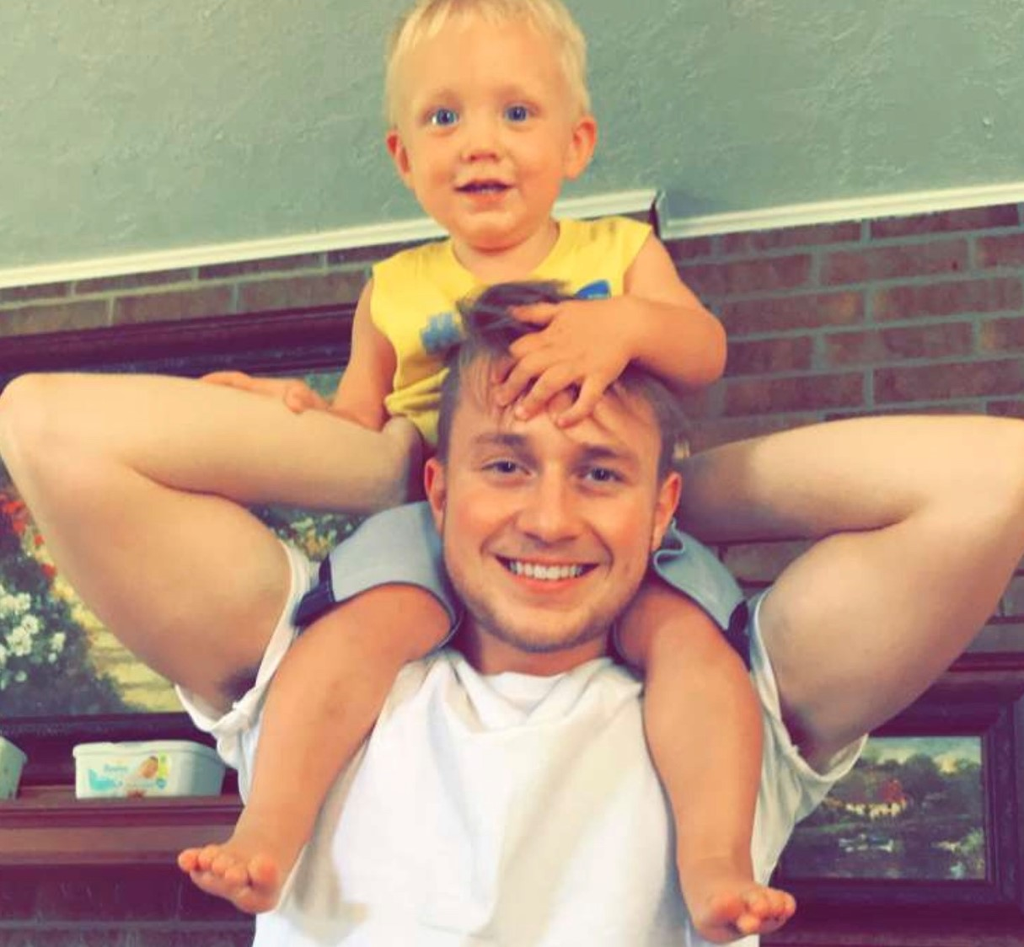

Kyle Murphey

# 1 Introduction

Wine is one of humanities oldest alcoholic beverages. It has been used recreationally, religiously, and medicinally throughout the millennia. Wine was seen as a creation by the Greek god Dionysos (or Bacchus, if you were Roman) to the people. It was said that the god gifted the vine to a man named Ikarios. Ikarios used this gift to make wine, which he was inclined to share with his fellow people. When he shared the wine, the others got freaked out by the effects, thinking that they had been poisoned. They ended up murdering Ikarios, and his creation spread from there. Image and information found: (see Cartwright 2020)

[figure not shown]

Dionysos, https://www.ancient.eu/uploads/images/884.jpg?v=1569519612

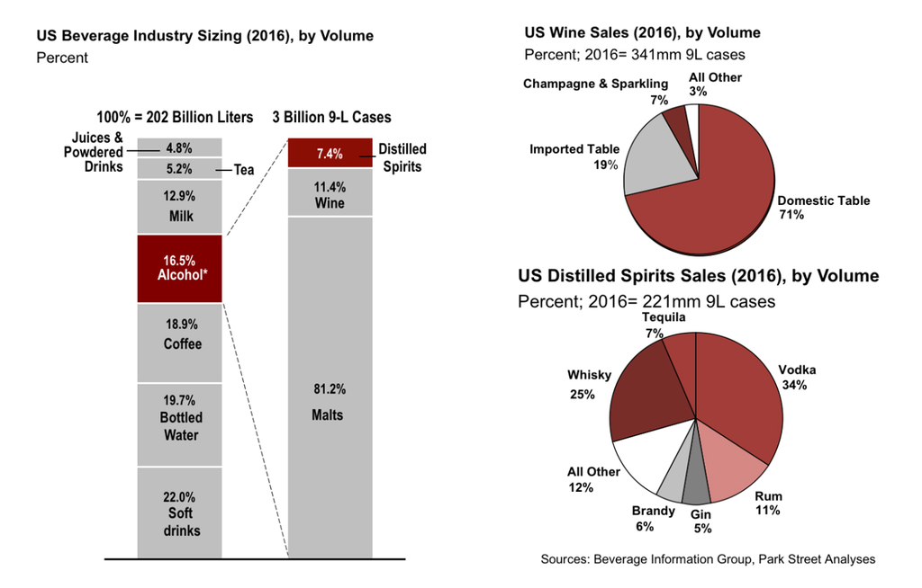

Beverage sale in the US, https://www.parkstreet.com/alcoholic-beverage-market-overview/

With that much wine being sold in just America alone, companies have plenty of motivation to produce quality wines for people to enjoy. When it comes to the quality of a wine, much is subjective. How do you quantify quality of taste? The wine must be tasted by humans in order to determine the quality. With such subjective testing, its difficult to find what properties of the wine that people like. In order to try to find a trend in quality, various physiochemical properties have been recorded along with their coinsiding quality rating in this dataset.

## 1.1 My Interest

I am a college student. Alcohol is well ingrained into the college culture. As a man who is part of said culture, I have had my fair share of alcoholic beverages. The more that my pallete has adjusted, the more I have become appreciative of wine. As a huge fan of juice growing up, it just makes sense that I make the gradual transition over to wine. It has quickly become one of my go-to drinks when it is available. With my growing interest in this drink, I have often wondered why some wines make me fall in love, whereas other wines make me fall over. This analysis is an attempt to seek out and identify the factors that contribute to this overall quality.

## 1.2 Data

This data is pulled from a 2009 study in which researchers at the University of Minho in Portugal attempted to predict taste preferences using physiochemical properties of red wine. The dataset contains 1599 samples with 11 different chemical properties and the qualities for each sample. The properties measured are the fixed acidity, volatile acidity, citric acid, residual sugar, chlorides, free sulfur dioxide, total sulfur dioxide, density, pH, sulphates, and alcohol. The quality is based on a scale of 1 (worst) to 10 (best).

```r
wine=read.csv("winequality-red.csv")
head(wine)
```

|  | fixed.acidity | volatile.acidity | citric.acid | residual.sugar | chlorides | free.sulfur.dioxide | total.sulfur.dioxide | density | pH | sulphates | alcohol | quality |
| --- | --- | --- | --- | --- | --- | --- | --- | --- | --- | --- | --- | --- |
| 1 | 7.4 | 0.70 | 0.00 | 1.9 | 0.076 | 11 | 34 | 0.9978 | 3.51 | 0.56 | 9.4 | 5 |
| 2 | 7.8 | 0.88 | 0.00 | 2.6 | 0.098 | 25 | 67 | 0.9968 | 3.20 | 0.68 | 9.8 | 5 |
| 3 | 7.8 | 0.76 | 0.04 | 2.3 | 0.092 | 15 | 54 | 0.9970 | 3.26 | 0.65 | 9.8 | 5 |
| 4 | 11.2 | 0.28 | 0.56 | 1.9 | 0.075 | 17 | 60 | 0.9980 | 3.16 | 0.58 | 9.8 | 6 |
| 5 | 7.4 | 0.70 | 0.00 | 1.9 | 0.076 | 11 | 34 | 0.9978 | 3.51 | 0.56 | 9.4 | 5 |
| 6 | 7.4 | 0.66 | 0.00 | 1.8 | 0.075 | 13 | 40 | 0.9978 | 3.51 | 0.56 | 9.4 | 5 |

## 1.3 The Problem to Solve

I will analyze the data in an attempt to find a correlation between the amount compounds in a wine and its overall quality. I do not expect all compounds to make a statistical difference in quality, but I am hoping to find at least a few. The results of this analysis will help me and anyone else who reads this make better guesses as to the quality of wine based on the compounds it contains.

## 1.4 Preliminary Plots and Interpretation of the Data

There are a lot of factors that could play a roll in the quality of the wine. I will show graphs of the wine quality given each compound below. Each compound come with 3 graphs: a scatterplot, a residual vs fitted, and a histogram. The scatter plots and histograms are to show the distribution of the data and the frequency. The residual vs fitted will be discussed later on in the document.

### 1.4.1 Quality~Fixed Acidity

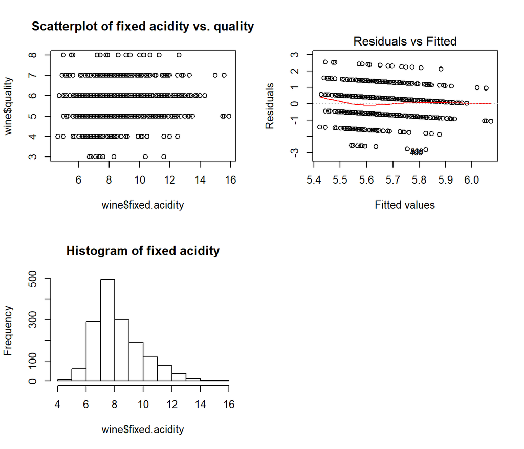

### 1.4.2 Quality~Volatile Acidity

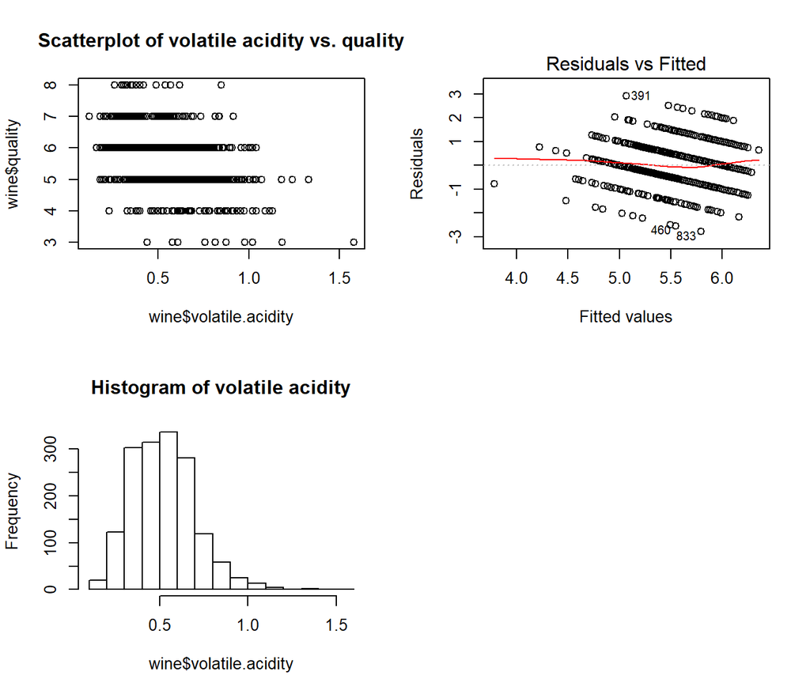

### 1.4.3 Quality~Citric Acid

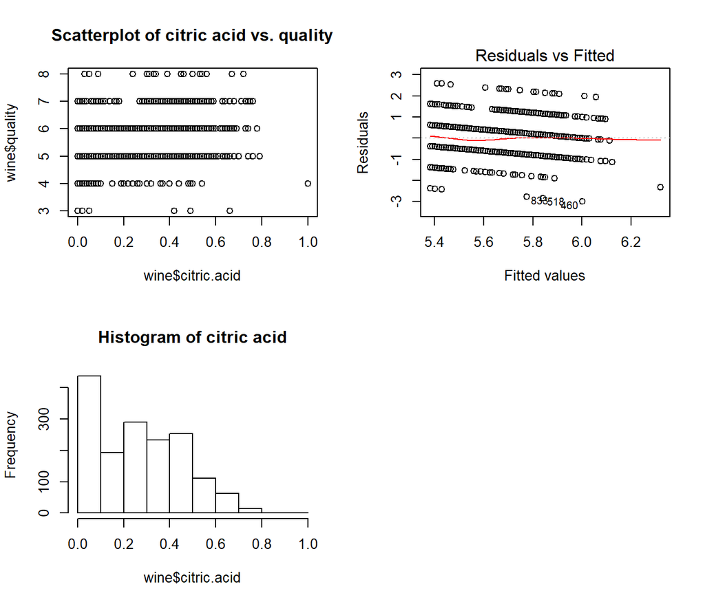

### 1.4.4 Quality~Residual Sugar

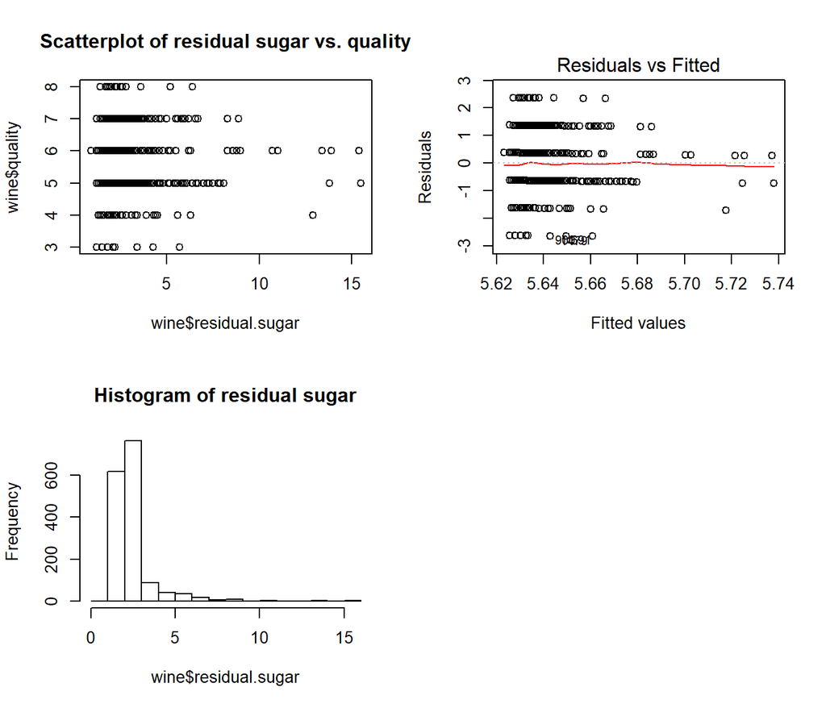

### 1.4.5 Quality~Chlorides

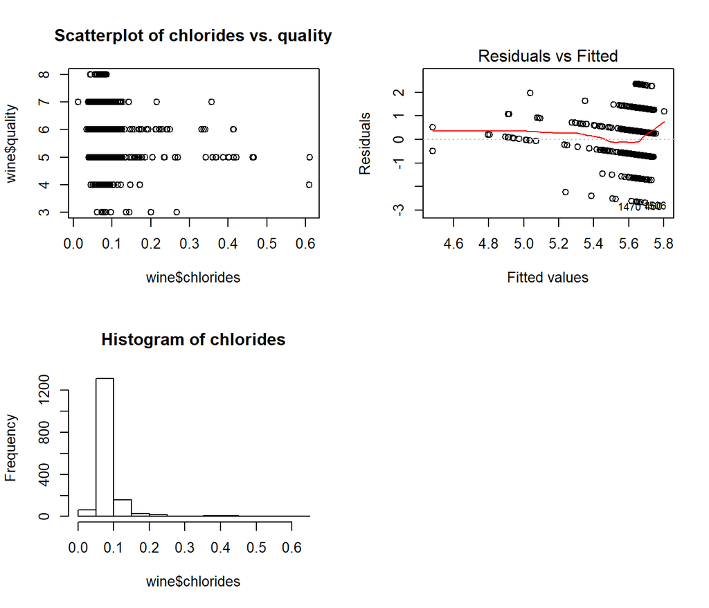

### 1.4.6 Quality~Free Sulfur Dioxide

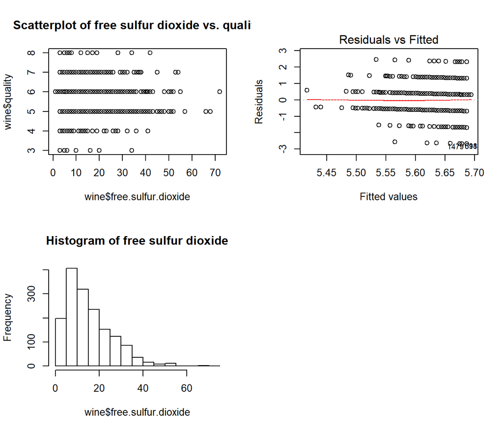

### 1.4.7 Quality~Total Sulfur Dioxide

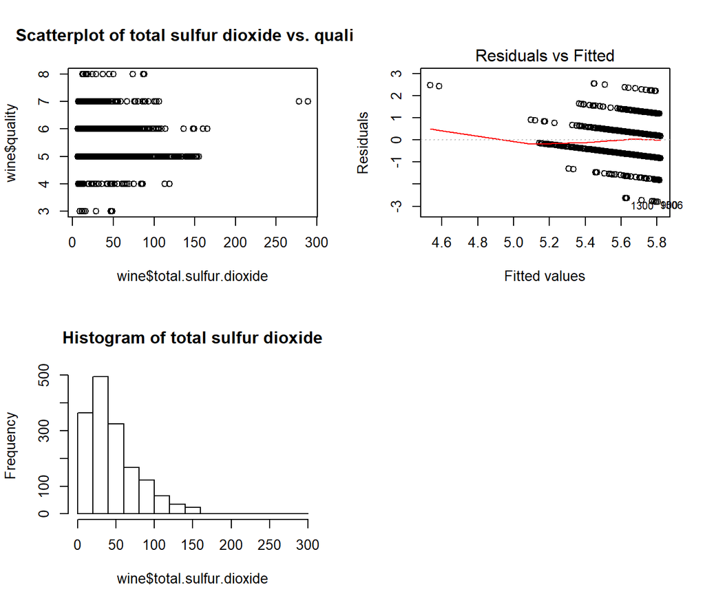

### 1.4.8 Quality~Density

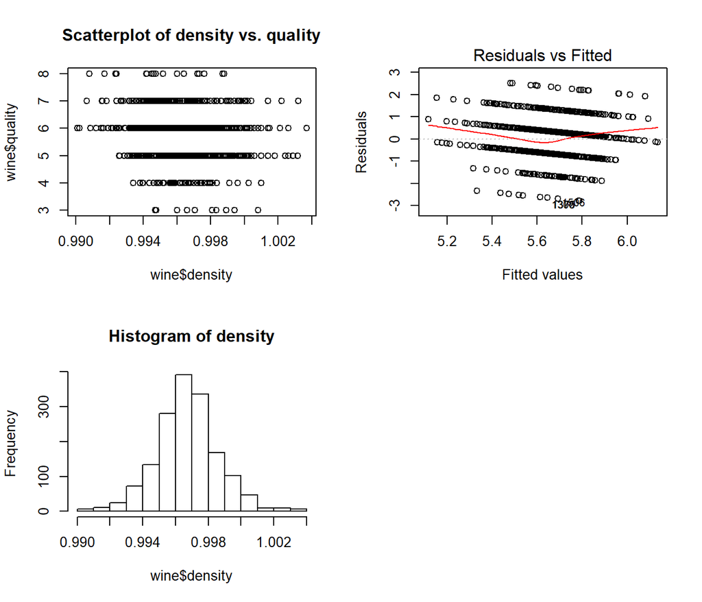

### 1.4.9 Quality~pH

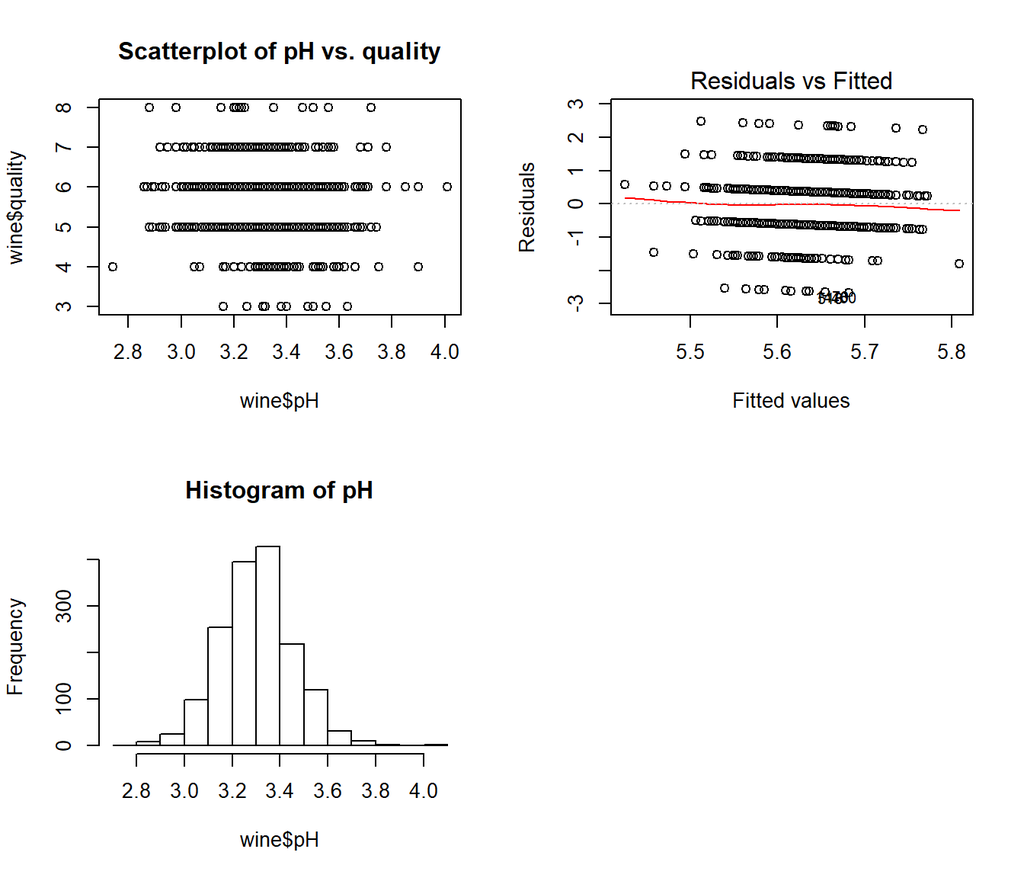

### 1.4.10 Quality~Sulphates

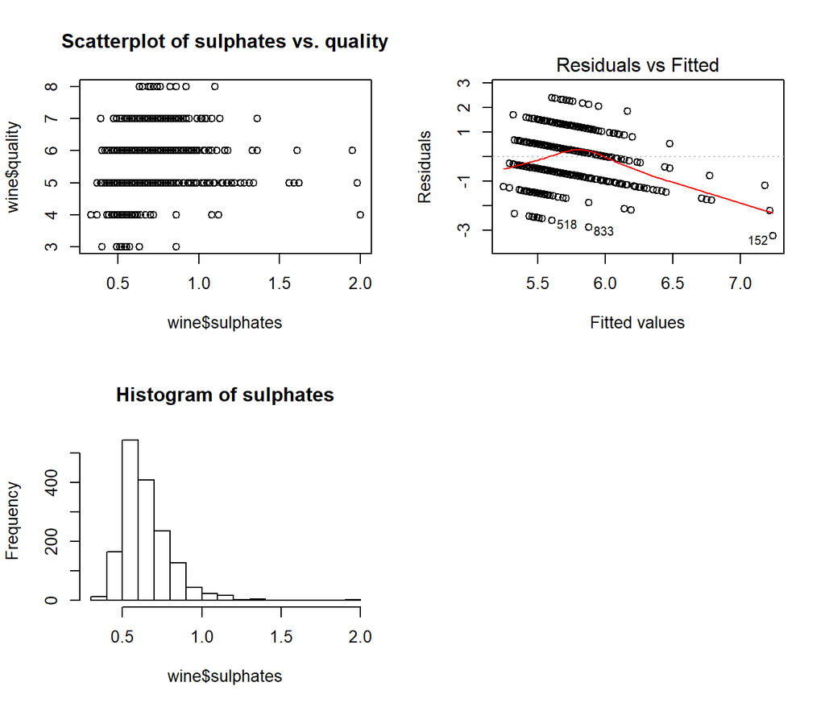

### 1.4.11 Quality~Alcohol

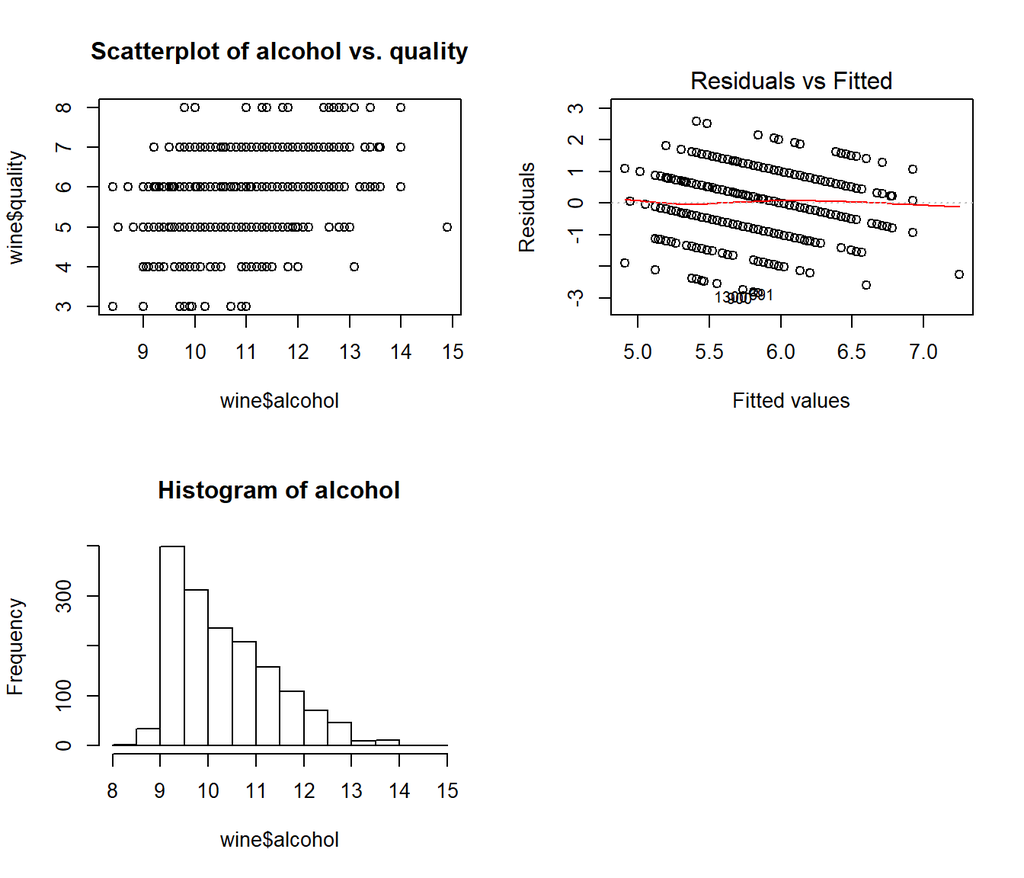

# 2 Theory behind the Analysis

As you can see in the preliminary graphs, the data appears scattered randomly, and that there isn’t much of a linear trend to analyze. I believe that the quality would drop given that too much of any one compound is in the wine. That being said, I will still attempt to find some linear correlation within the data, even if the relationship is minimal. The histograms show that the independent variables have an uneven distribution of the frequency of values tested. This can cause unexpected and faux trends in the data. Even though this may skew some results, I will conveniently ignore those facts in order to produce some sort of regressional analysis. I will be make a probabilistic model of a simple linear regression. The model assumes that the line produce by $\bar{y}$ given any value of $x$. Any deviating points are are represented by $\epsilon$. The equation of the line is:
$$y=\beta_0+\beta_1x_i+\epsilon_i$$
The variables $\beta_0$, $\beta_1$, and $\epsilon_i$ are as follows: $\beta_0$ and $\beta_1$ are random variables, and $\epsilon_i$ is the random error. If you drop $\epsilon_i$, you get the equation for $\bar{y}$ given any value of $x$. This can be represented as such:
$$E(y)=E(\beta_0+\beta_1x_i+\epsilon_i)$$
$$=\beta_0+\beta_1x_i+E(\epsilon_i)$$
$$=\beta_0+\beta_1x_i$$
Given this information, we can represent this as $E(Y|x)$ where $\beta_0$ is the y-intercept and $\beta_1$ is the slope. According to Mendenhall and Sinich 2016 (see Mendenhall and Sincich 2016), we need to make the following assumptions about $\epsilon$ in order to estimate the $\beta$ parameters. These assumptions are:

- The mean of the probability distribution of $\epsilon$ is 0.
- The variance of the probability distribution of $\epsilon$ is constant for all settings of the independent variable x.
- The probability distribution of $\epsilon$ is normal.
- The error associated with one value of y has no effect on the errors associated with other y values.

Given these assumptions, we should be able to produce some estimates for the $\beta$ parameters.

# 3 Estimating the Parameters

Since the data isn’t very linear and there are a lot of independent variables, I will be selecting 2 independent variables that show the best fit based on their multiple $R^2$ value. The 2 variables with the highest multiple $R^2$ values are alcohol and volatile acidity.

```r
summary(wine.alc)
```

```
##
## Call:
## lm(formula = wine$quality ~ wine$alcohol, data = wine)
##
## Residuals:
##     Min      1Q  Median      3Q     Max
## -2.8442 -0.4112 -0.1690  0.5166  2.5888
##
## Coefficients:
##              Estimate Std. Error t value Pr(>|t|)
## (Intercept)   1.87497    0.17471   10.73   <2e-16 ***
## wine$alcohol  0.36084    0.01668   21.64   <2e-16 ***
## ---
## Signif. codes:  0 '***' 0.001 '**' 0.01 '*' 0.05 '.' 0.1 ' ' 1
##
## Residual standard error: 0.7104 on 1597 degrees of freedom
## Multiple R-squared:  0.2267, Adjusted R-squared:  0.2263
## F-statistic: 468.3 on 1 and 1597 DF,  p-value: < 2.2e-16
```

```r
summary(wine.va)
```

```
##
## Call:
## lm(formula = wine$quality ~ wine$volatile.acidity, data = wine)
##
## Residuals:
##      Min       1Q   Median       3Q      Max
## -2.79071 -0.54411 -0.00687  0.47350  2.93148
##
## Coefficients:
##                       Estimate Std. Error t value Pr(>|t|)
## (Intercept)            6.56575    0.05791  113.39   <2e-16 ***
## wine$volatile.acidity -1.76144    0.10389  -16.95   <2e-16 ***
## ---
## Signif. codes:  0 '***' 0.001 '**' 0.01 '*' 0.05 '.' 0.1 ' ' 1
##
## Residual standard error: 0.7437 on 1597 degrees of freedom
## Multiple R-squared:  0.1525, Adjusted R-squared:  0.152
## F-statistic: 287.4 on 1 and 1597 DF,  p-value: < 2.2e-16
```

With multiple $R^2$ values of 0.2267 and 0.1525, respectively. While very low, they are the best I have to work with. Based on these summaries, we can say that
$$\hat{\beta_{0a}}=1.87497$$
$$\hat{\beta_{1a}}=0.36084$$
and
$$\hat{\beta_{0v}}=6.56575$$
$$\hat{\beta_{1v}}=-1.76144$$

## 3.1 Confidence Interval

```r
ciReg(wine.alc,conf.level=0.95,print.out=TRUE)
```

```
##              95 % C.I.lower    95 % C.I.upper
## (Intercept)         1.53229           2.21766
## wine$alcohol        0.32813           0.39355
```

```r
ciReg(wine.va,conf.level=0.95,print.out=TRUE)
```

```
##                       95 % C.I.lower    95 % C.I.upper
## (Intercept)                  6.45217           6.67932
## wine$volatile.acidity       -1.96522          -1.55765
```

## 3.2 The Least-Squares Estimates

$$\hat{\beta_{0a}}+\hat{\beta_{1a}}x_i=1.87497+0.36084x_i$$
$$\hat{\beta_{0v}}+\hat{\beta_{1v}}x_i=6.56575-1.76144x_i$$
The slope $\hat{\beta_{1a}}=0.36084$ tells us that the quality rises 0.36084 for every 1 increase in alcohol. The slope $\hat{\beta_{1v}}=-1.76144$ tells us that the quality lowers 1.76144 for every 1 increase in volatile acidity.

# 4 Verifying Assumptions

I will attempt to verify the above assumptions to show whether or not a straight line is the best fit for the model.

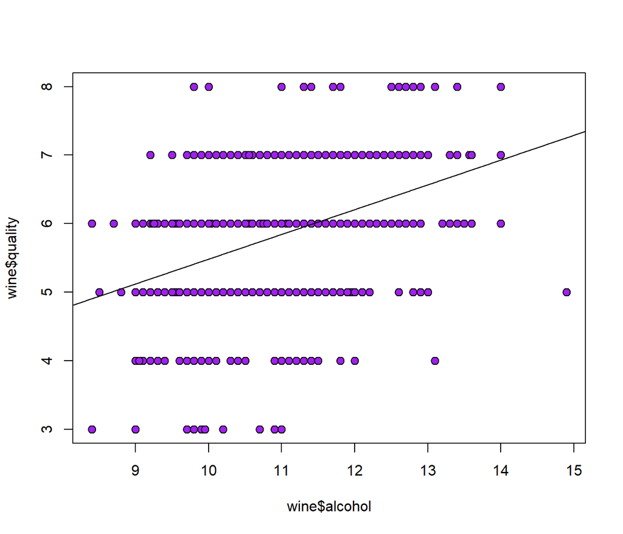

```r
plot(wine$quality~wine$alcohol,bg="Purple",pch=21,cex=1.2,data=wine)
abline(wine.alc)
```

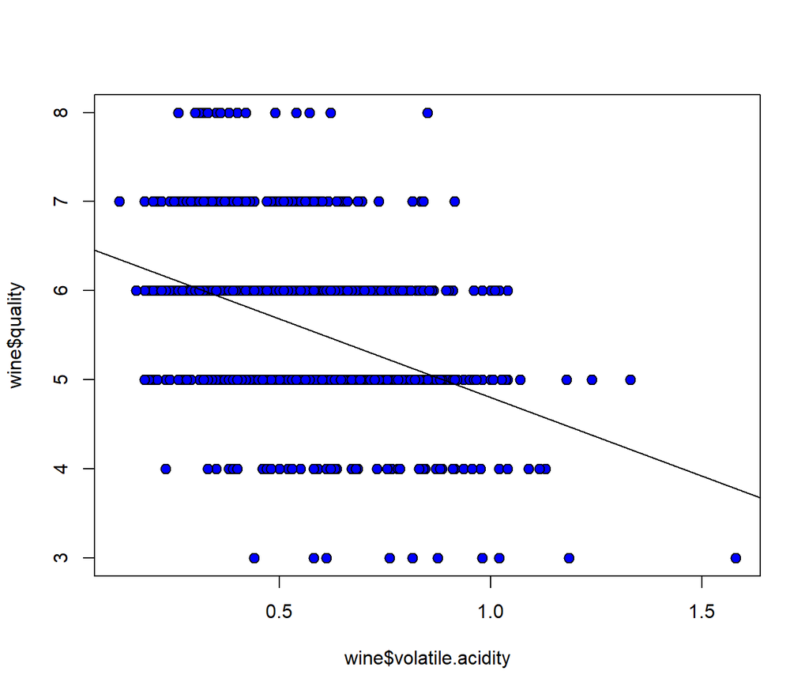

```r
plot(wine$quality~wine$volatile.acidity,bg="Blue",pch=21,cex=1.2,data=wine)
abline(wine.va)
```

These plots do not indicate that a linear model is the best fit for the data.

## 4.1 Plot Residuals

The residuals tell us by how much points deviate from the fitted line. They help us to see just how far the points are varying from the line.

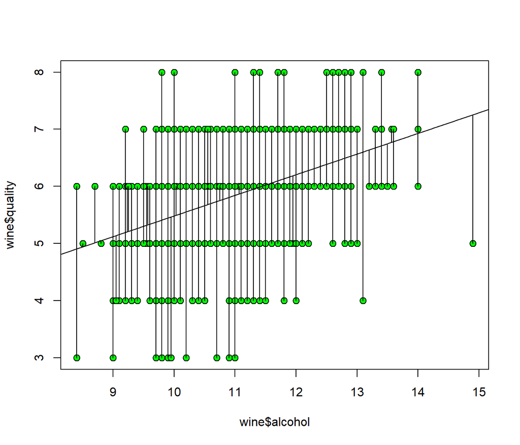

```r
plot(wine$quality~wine$alcohol,bg="Green",pch=21,cex=1.2,data=wine)
abline(wine.alc)
yhata=with(wine,predict(wine.alc,data.frame(alcohol)))
with(wine,{segments(alcohol,quality,alcohol,yhata)})
abline(wine.alc)
```

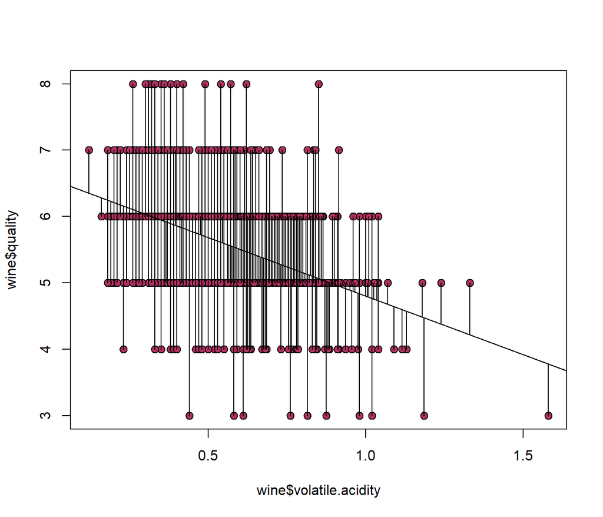

```r
plot(wine$quality~wine$volatile.acidity,bg="Maroon",pch=21,cex=1.2,data=wine)
abline(wine.va)
yhatv=with(wine,predict(wine.va,data.frame(volatile.acidity)))
with(wine,{segments(volatile.acidity,quality,volatile.acidity,yhatv)})
abline(wine.va)
```

As you can see, there is *quite* a lot of deviation from the line.

## 4.2 Plot of Means

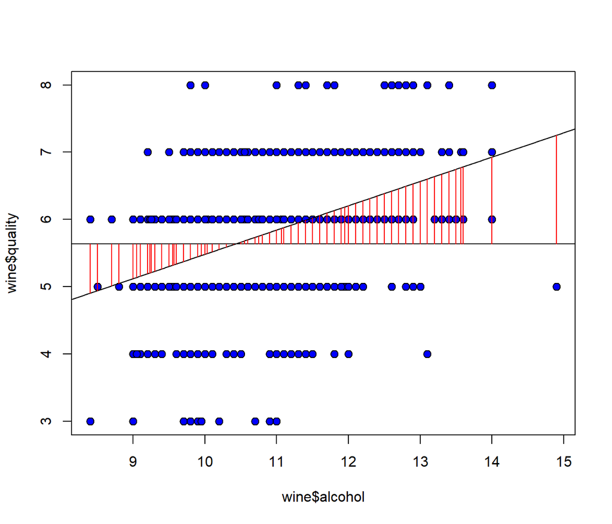

```r
plot(wine$quality~wine$alcohol,bg="Blue",pch=21,cex=1.2,data=wine)
abline(wine.alc)
with(wine,abline(h=mean(quality)))
abline(wine.alc)
with(wine,{segments(alcohol,mean(quality),alcohol,yhata,col="Red")})
```

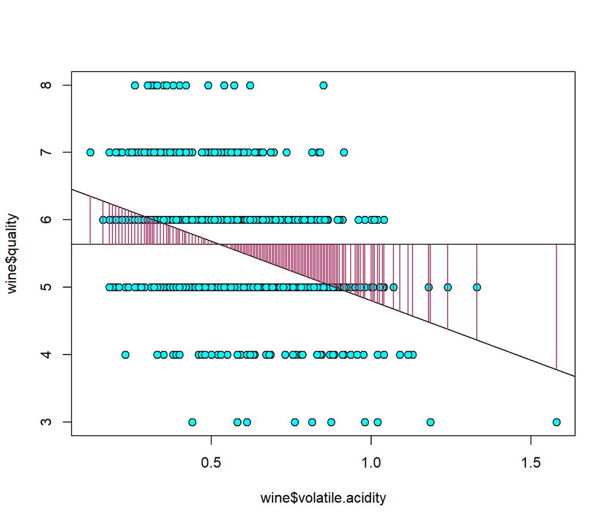

```r
plot(wine$quality~wine$volatile.acidity,bg="Cyan",pch=21,cex=1.2,data=wine)
abline(wine.va)
with(wine,abline(h=mean(quality)))
abline(wine.va)
with(wine,{segments(volatile.acidity,mean(quality),volatile.acidity,yhatv,col="maroon")})
```

## 4.3 Plot of Means with Total Deviation Line Segments

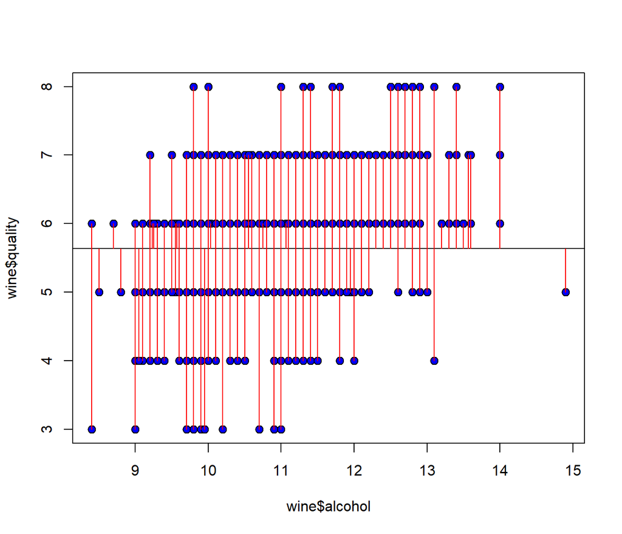

```r
plot(wine$quality~wine$alcohol,bg="Blue",pch=21,cex=1.2,data=wine)
with(wine,abline(h=mean(quality)))
with(wine,{segments(alcohol,quality,alcohol,mean(quality),col="Red")})
```

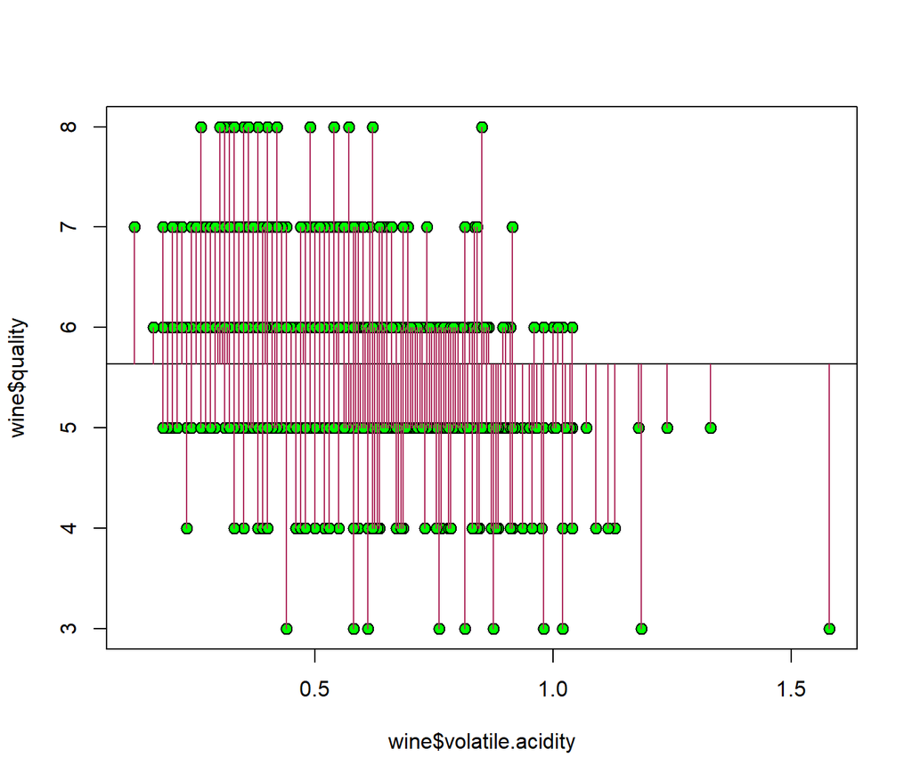

```r
plot(wine$quality~wine$volatile.acidity,bg="Green",pch=21,cex=1.2,data=wine)
with(wine,abline(h=mean(quality)))
with(wine,{segments(volatile.acidity,quality,volatile.acidity,mean(quality),col="Maroon")})
```

## 4.4 Using RSS, MSS, and TSS

```r
RSSa=with(wine,sum((quality-yhata)^2))
RSSa
```

```
## [1] 805.8705
```

```r
MSSa=with(wine,sum((yhata-mean(quality))^2))
MSSa
```

```
## [1] 236.2946
```

```r
TSSa=with(wine,sum((quality-mean(quality))^2))
TSSa
```

```
## [1] 1042.165
```

```r
RSSv=with(wine,sum((quality-yhatv)^2))
RSSv
```

```
## [1] 883.1981
```

```r
MSSv=with(wine,sum((yhatv-mean(quality))^2))
MSSv
```

```
## [1] 158.967
```

```r
TSSv=with(wine,sum((quality-mean(quality))^2))
TSSv
```

```
## [1] 1042.165
```

Since $R^2$ = $\frac{MSS}{TSS}$, which will be the value for the trend line. The higher the percentage, the better the fit for the data.

```r
MSSa/TSSa
```

```
## [1] 0.2267344
```

```r
MSSv/TSSv
```

```
## [1] 0.1525354
```

## 4.5 Specifying the Probability Distribution

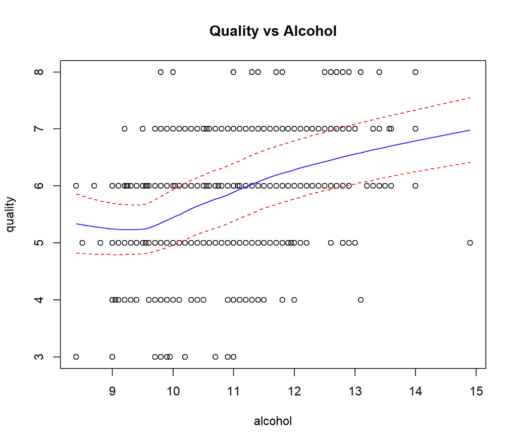

```r
trendscatter(quality~alcohol,f=0.5,data=wine,main="Quality vs Alcohol")
```

Based on this trend, the quality rises as the alcohol levels do.

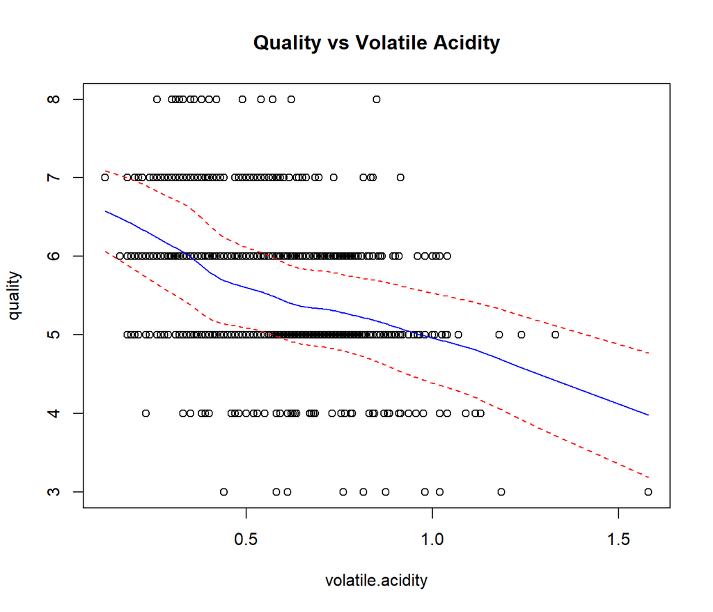

```r
trendscatter(quality~volatile.acidity,f=0.5,data=wine,main="Quality vs Volatile Acidity")
```

Based on this trend, the quality lowers as the volatile acidity levels increase

Residuals:

```r
wine.resa=residuals(wine.alc)
wine.resv=residuals(wine.va)
```

Fitted:

```r
wine.fita=fitted(wine.alc)
wine.fitv=fitted(wine.va)
```

## 4.6 Plot the Residuals vs Alcohol

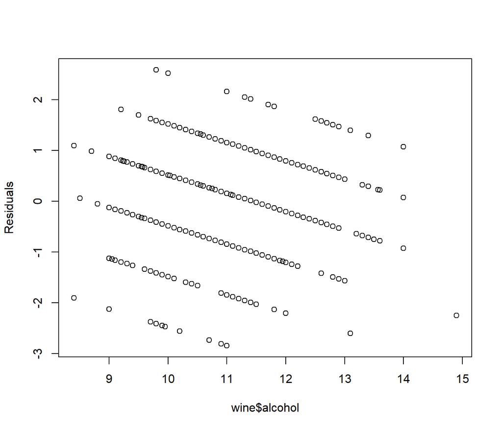

```r
plot(wine$alcohol,wine.resa,ylab="Residuals")
```

The residuals are not symmetrically distributed about 0 on the y-axis, this tells us that there is a lot of deviation from the best fit line.

## 4.7 Plot the Residuals vs Volatile Acidity

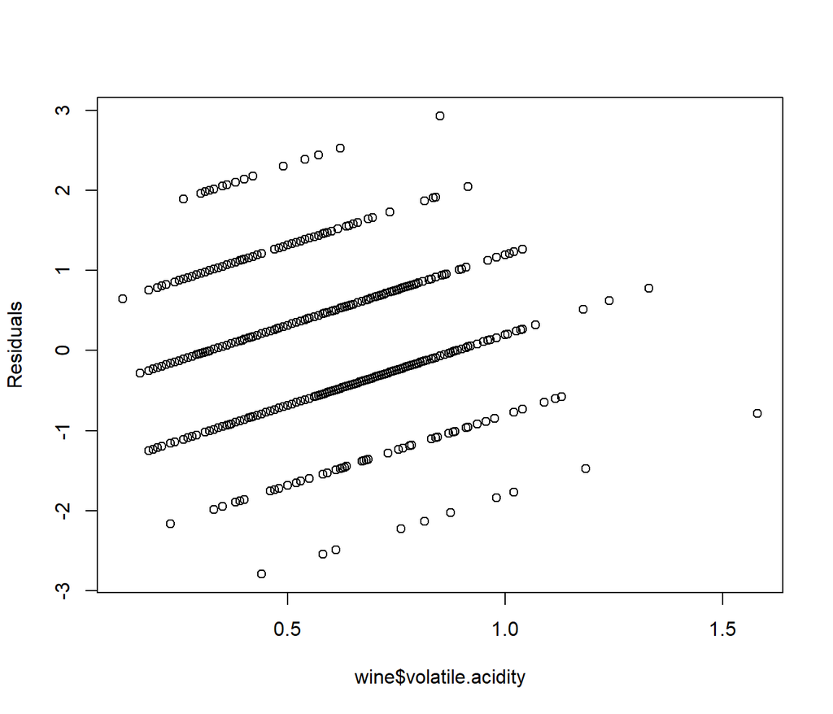

```r
plot(wine$volatile.acidity,wine.resv,ylab="Residuals")
```

The residuals are not symmetrically distributed about 0 on the y-axis, this tells us that there is a lot of deviation from the best fit line.

## 4.8 Plot the Residuals vs Alcohol Fitted values

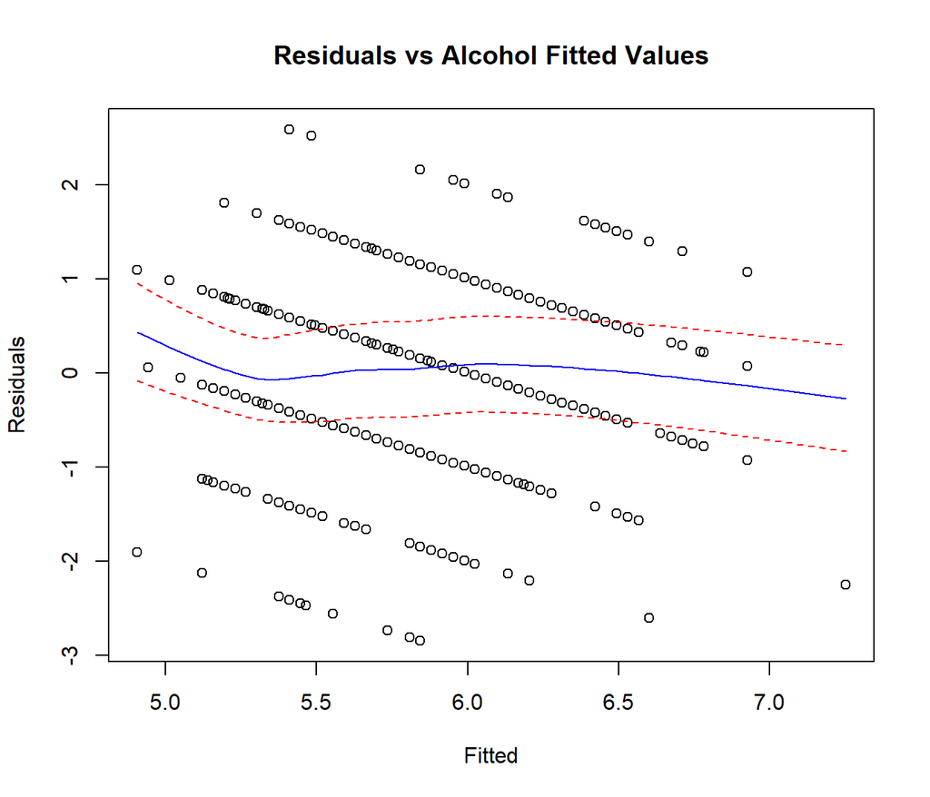

```r
trendscatter(wine.resa~wine.fita,f=0.5,data=wine.alc,xlab="Fitted",ylab="Residuals",main="Residuals vs Alcohol Fitted Values")
```

The line is not very straight about 0 on the y-axis, so the plot is “unsatisfactory”.

## 4.9 Plot the Residuals vs Volatile Acidity Fitted values

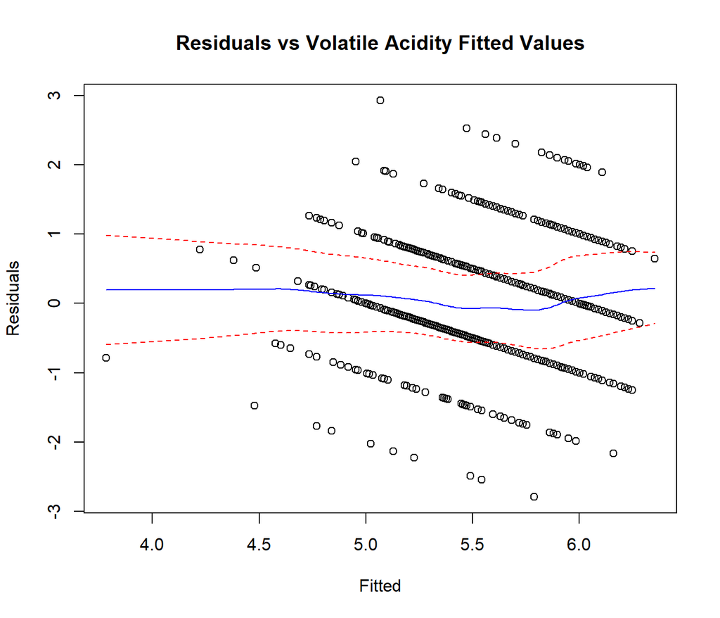

```r
trendscatter(wine.resv~wine.fitv,f=0.5,data=wine.alc,xlab="Fitted",ylab="Residuals",main="Residuals vs Volatile Acidity Fitted Values")
```

The line is not very straight about 0 on the y-axis, so the plot is “unsatisfactory”.

## 4.10 Check Normality

### 4.10.1 Alcohol

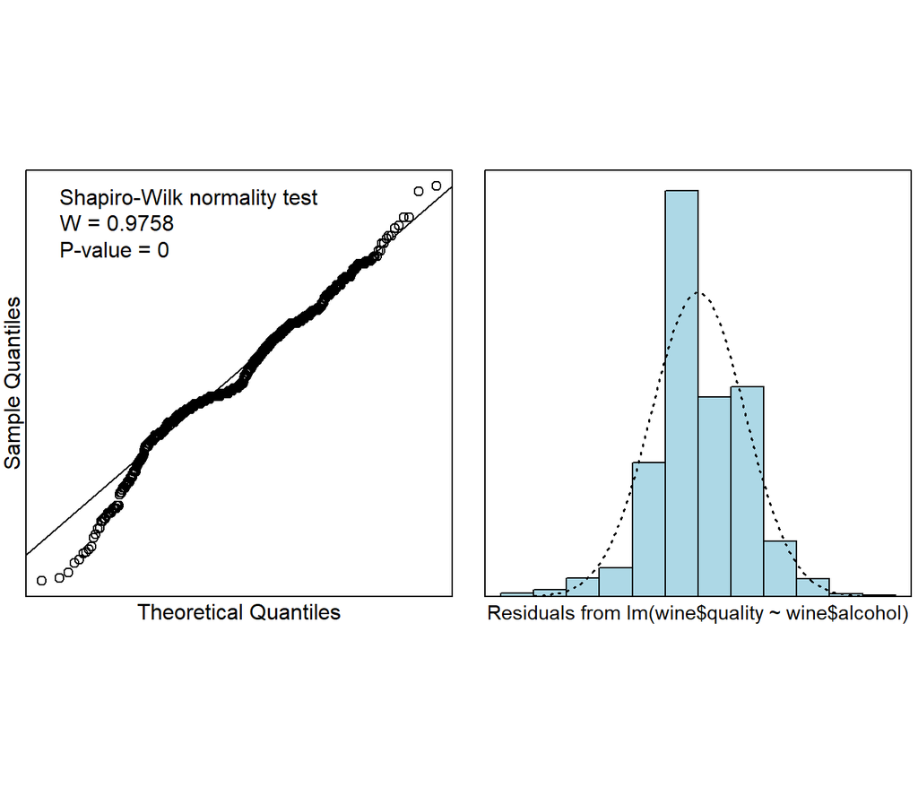

```r
normcheck(wine.alc,shapiro.wilk=TRUE)
```

We obtain a p-value of 0, so we reject the Null hypothesis that the errors are distributed normally. The results of the Shapiro-Wilk test tell us that we have enough evidence to reject the null hypothesis (p-value of 0). This tells us that the data is not distributed normally.

### 4.10.2 Volatile Acidity

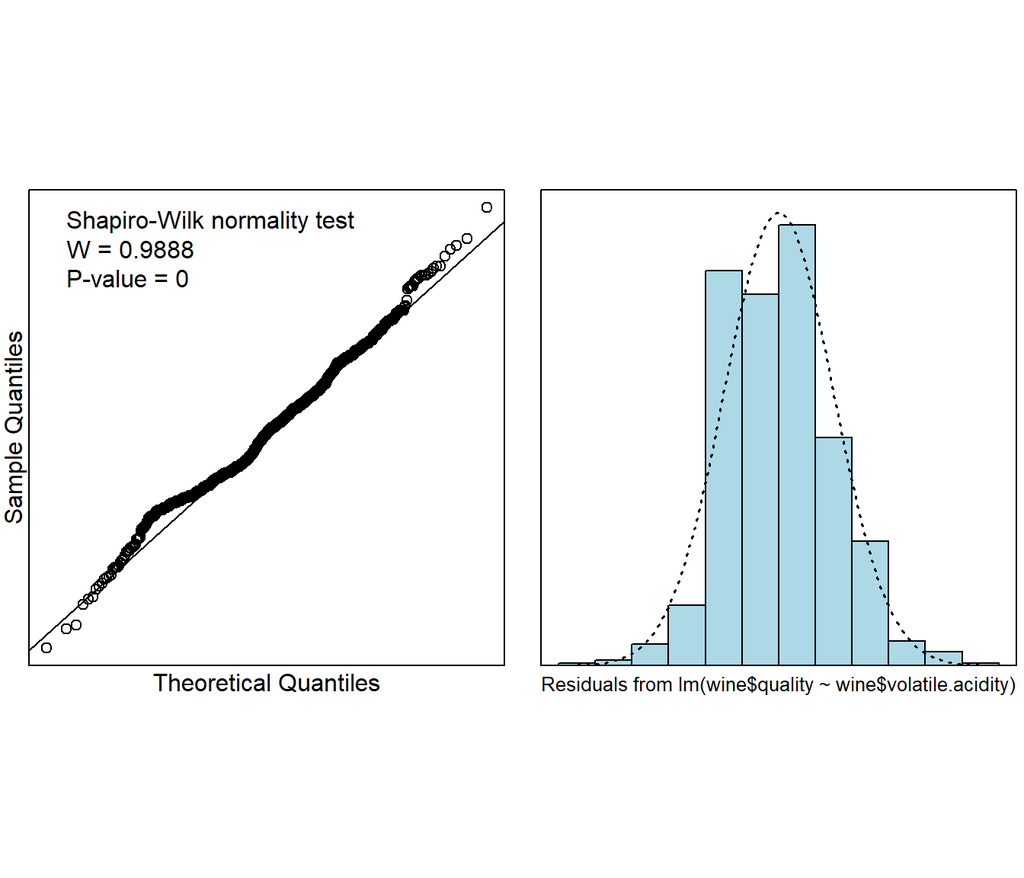

```r
normcheck(wine.va,shapiro.wilk=TRUE)
```

We obtain a p-value of 0, so we reject the Null hypothesis that the errors are distributed normally. The results of the Shapiro-Wilk test tell us that we have enough evidence to reject the null hypothesis (p-value of 0). This tells us that the data is not distributed normally.

## 4.11 Testing Another Model

As we can see, a linear model is not the best model for the data. Here, we will test a quadratic model for the dataset.

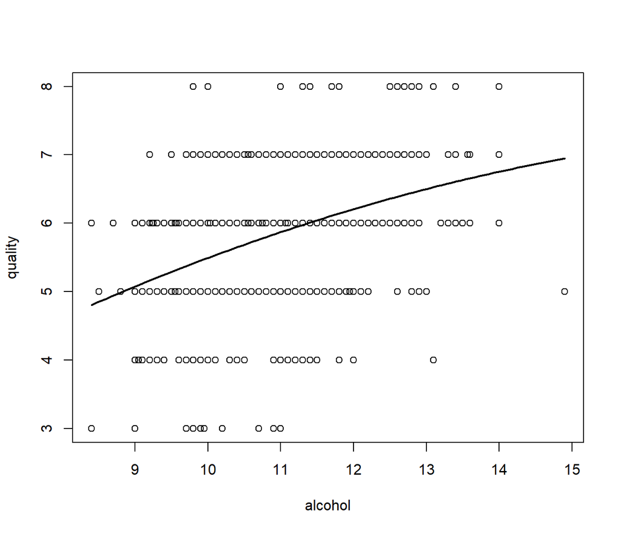

```r
quada.lm=lm(quality~alcohol+I(alcohol^2),data=wine)
plot(quality~alcohol,data=wine)
myplot=function(x){quada.lm$coef[1]+quada.lm$coef[2]*x+quada.lm$coef[3]*x^2}
curve(myplot,lwd=2,add=TRUE)
```

```r
summary(quada.lm)
```

```
##
## Call:
## lm(formula = quality ~ alcohol + I(alcohol^2), data = wine)
##
## Residuals:
##     Min      1Q  Median      3Q     Max
## -2.8716 -0.3884 -0.1642  0.5157  2.5852
##
## Coefficients:
##              Estimate Std. Error t value Pr(>|t|)
## (Intercept)  -0.53568    1.52768  -0.351  0.72590
## alcohol       0.80902    0.28265   2.862  0.00426 **
## I(alcohol^2) -0.02059    0.01297  -1.588  0.11240
## ---
## Signif. codes:  0 '***' 0.001 '**' 0.01 '*' 0.05 '.' 0.1 ' ' 1
##
## Residual standard error: 0.71 on 1596 degrees of freedom
## Multiple R-squared:  0.228,  Adjusted R-squared:  0.227
## F-statistic: 235.6 on 2 and 1596 DF,  p-value: < 2.2e-16
```

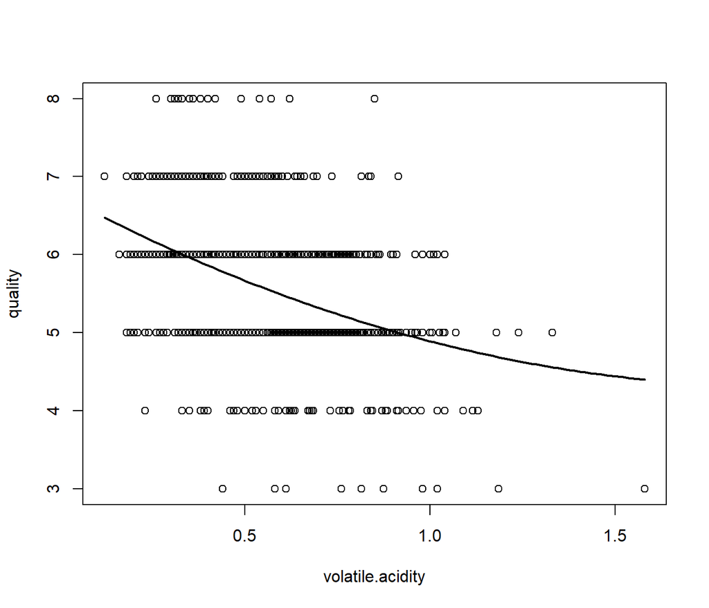

```r
quadv.lm=lm(quality~volatile.acidity+I(volatile.acidity^2),data=wine)
plot(quality~volatile.acidity,data=wine)
myplot=function(x){quadv.lm$coef[1]+quadv.lm$coef[2]*x+quadv.lm$coef[3]*x^2}
curve(myplot,lwd=2,add=TRUE)
```

```r
summary(quadv.lm)
```

```
##
## Call:
## lm(formula = quality ~ volatile.acidity + I(volatile.acidity^2),
##     data = wine)
##
## Residuals:
##     Min      1Q  Median      3Q     Max
## -2.7817 -0.5209 -0.0412  0.4791  2.9099
##
## Coefficients:
##                       Estimate Std. Error t value Pr(>|t|)
## (Intercept)             6.7679     0.1226  55.220  < 2e-16 ***
## volatile.acidity       -2.5283     0.4228  -5.980 2.75e-09 ***
## I(volatile.acidity^2)   0.6522     0.3486   1.871   0.0615 .
## ---
## Signif. codes:  0 '***' 0.001 '**' 0.01 '*' 0.05 '.' 0.1 ' ' 1
##
## Residual standard error: 0.7431 on 1596 degrees of freedom
## Multiple R-squared:  0.1544, Adjusted R-squared:  0.1533
## F-statistic: 145.7 on 2 and 1596 DF,  p-value: < 2.2e-16
```

The line is very similar to the linear trend line, so this model probably isn’t the best either. However, the multiple $R^2$ value slightly increased for each, so it is a better fit than the linear model.